# Nonparametric Testing

Yan Shuo Tan

```r
knitr::opts_chunk$set(echo = TRUE)
library(tidyverse)
library(coin)
source("util.R")
```

## T-test failure

```r
n_samples <- 100
sales_figs <- make_sales_figs(n_samples, seed=42)
sales_figs
```

```
## # A tibble: 100 × 2
##    Dwight   Jim
##     <dbl> <dbl>
##  1    234   220
##  2     56   100
##  3     72    86
##  4     10   100
##  5    363    91
##  6     32    69
##  7    323   330
##  8     61    82
##  9     39    54
## 10    277   279
## # … with 90 more rows
```

```r
sales_means <- sales_figs %>% map_dbl(mean)
sales_means
```

```
## Dwight    Jim
## 143.52 167.34
```

Jim has a higher mean sales figure than Dwight. Is Jim a better salesperson? Or was this just luck? To test this rigorously, do statistical hypothesis testing.

Let $X_1,X_2,\ldots,X_n$ be the daily sales numbers for Jim, and let $Y_1,Y_2,\ldots,Y_n$ be the daily sales numbers for Dwight. Suppose that all observations are independent of each other, and furthermore that $X_i \sim N(\mu_X,\sigma_X^2)$, $Y_i \sim N(\mu_Y, \sigma_Y^2)$ for $i=1,\ldots,n$. We set up the following null and alternate hypotheses
$$H_0: \mu_X = \mu_Y$$
$$H_1: \mu_X > \mu_Y$$
The standard test for these two hypotheses, if $\sigma_X$ and $\sigma_Y$ are unknown, is to do a (two-sample) $t$-test:
$$t = \frac{\bar{X} - \bar{Y}}{\sqrt{\hat{\sigma}_X^2/n +
\hat{\sigma}_Y^2/n}},$$
where
$$\hat\sigma_X^2 = \frac{1}{n-1}\sum_{i=1}(X_i - \bar X)^2,
\quad\hat\sigma_Y^2 = \frac{1}{n-1}\sum_{i=1}(Y_i - \bar Y)^2$$
Can check that this is the likelihood ratio test for this problem. Let’s now do the test:

```r
t_test <- t.test(sales_figs$Jim, sales_figs$Dwight, alternative = "greater")
t_test
```

```
##
##  Welch Two Sample t-test
##
## data:  sales_figs$Jim and sales_figs$Dwight
## t = 1.3804, df = 197.76, p-value = 0.08451
## alternative hypothesis: true difference in means is greater than 0
## 95 percent confidence interval:
##  -4.697216       Inf
## sample estimates:
## mean of x mean of y
##    167.34    143.52
```

We get a p-value of 0.085, i.e. not significant… But let’s check if the assumptions for the test hold.

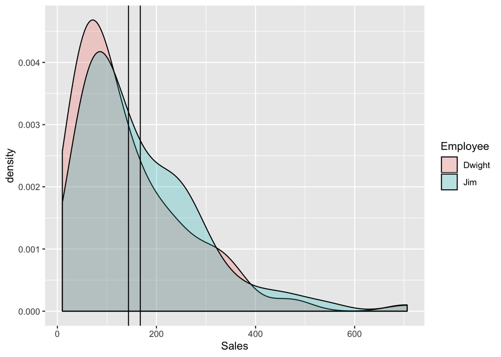

```r
sales_figs %>% pivot_longer(cols = c("Jim", "Dwight"), names_to = "Employee", values_to = "Sales") %>%
  ggplot() + geom_density(aes(x = Sales, fill = Employee), alpha=0.25) + geom_vline(xintercept = sales_means)
```

The distributions are clearly non-Gaussian. Should use a nonparametric test instead… (back to slides) We will do a permutation test.

## Non-parametric two independent sample tests

[figure not shown]

```r
perm_results <- get_tstat_perm_results(sales_figs$Jim, sales_figs$Dwight)
annotation <- tibble(
   x = c(2.2, 2.4),
   y = c(0.3, 0.1),
   label = c("t-statistic value = 0.12", sprintf("area = %.5f", mean(perm_results > t_test$statistic)))
)
ggplot(tibble(Permuted_values = perm_results)) + geom_density(aes(x = Permuted_values), fill = "red", alpha = 0.25) +
  geom_vline(xintercept = t_test$statistic) + geom_text(data = annotation, aes(x = x, y = y, label = label))
```

```r
mean(perm_results > t_test$statistic)
```

```
## [1] 0.0823
```

The p-value doesn’t change very much, but at least we can rest assured that it is legitimate and does not rely on false assumptions. How can we increase the power of our test? (back to slides) Solution is to use ranks to remove the influence of extreme values. The name of this test is the Mann-Whitney U-test.

```r
sales_long <- sales_figs %>% pivot_longer(cols = c("Jim", "Dwight"), names_to = "Employee", values_to = "Sales") %>% transmute(Employee = factor(Employee, levels = c("Jim", "Dwight")), Sales)
wilcox_test(Sales ~ Employee, data = sales_long, alternative = "greater")
```

```
##
##  Asymptotic Wilcoxon-Mann-Whitney Test
##
## data:  Sales by Employee (Jim, Dwight)
## Z = 1.7813, p-value = 0.03743
## alternative hypothesis: true mu is greater than 0
```

We now repeat this experiment 500 times with different random seeds

```r
n_reps <- 500
t_test_results <- rep(0, n_reps)
mw_test_results <- rep(0, n_reps)
for (i in seq(n_reps)) {
  sales_figs_temp <- make_sales_figs(n_samples)
  t_test_results[i] <- t.test(sales_figs$Jim, sales_figs$Dwight, alternative = "greater")$p.value
  sales_long <- sales_figs_temp %>% pivot_longer(cols = c("Jim", "Dwight"), names_to = "Employee", values_to = "Sales") %>%
    transmute(Employee = factor(Employee, levels = c("Jim", "Dwight")), Sales)
  mw_test_results[i] <- wilcox_test(Sales ~ Employee, data = sales_long, alternative = "greater") %>% pvalue
}
tibble(t_test = t_test_results, mw_test = mw_test_results) %>% map_dbl(mean)
```

```
##     t_test    mw_test
## 0.08451278 0.05332377
```

## Paired sample tests

Can we improve the power of our test even more?

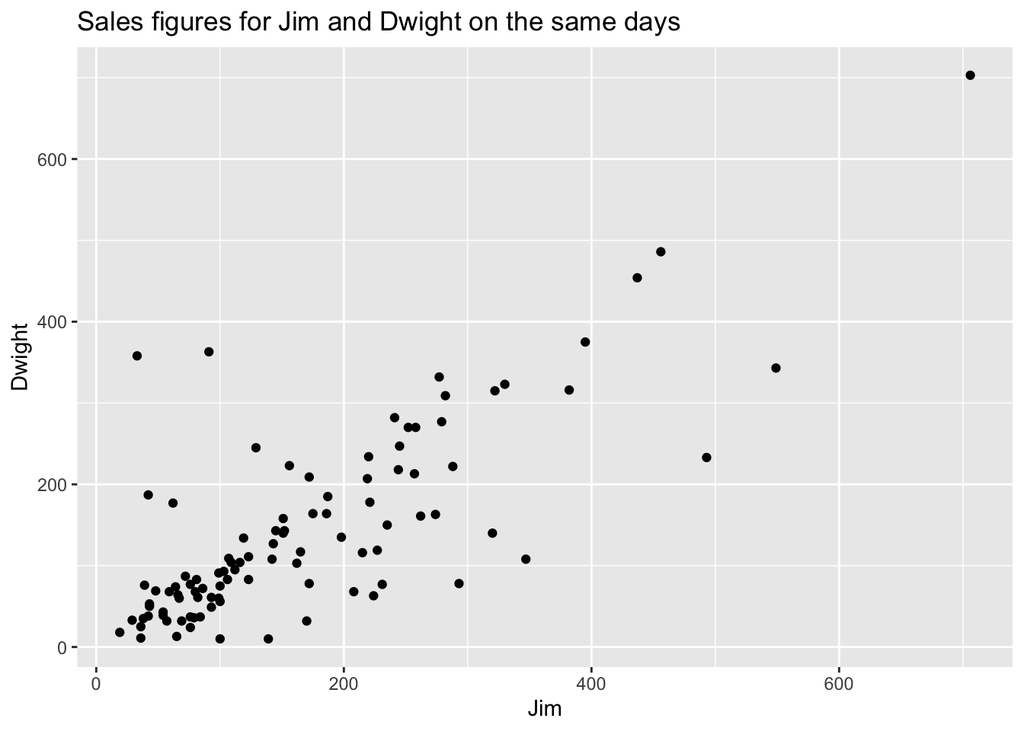

```r
ggplot(sales_figs) + geom_point(aes(x = Jim, y = Dwight)) + ggtitle("Sales figures for Jim and Dwight on the same days")
```

We see that there is strong positive correlation between the sales numbers of both employees. This is natural because there are time-varying effects, e.g. there may be more demand for paper products on some days (e.g. close to tax season). To exploit this, we should use a paired sample test.

```r
t_test <- t.test(sales_figs$Jim, sales_figs$Dwight, paired = TRUE, alternative = "greater")
t_test
```

```
##
##  Paired t-test
##
## data:  sales_figs$Jim and sales_figs$Dwight
## t = 2.9264, df = 99, p-value = 0.002127
## alternative hypothesis: true difference in means is greater than 0
## 95 percent confidence interval:
##  10.30492      Inf
## sample estimates:
## mean of the differences
##                   23.82
```

```r
signed_rank_test <- wilcox.test(sales_figs$Jim, sales_figs$Dwight, paired = TRUE, alternative = "greater")
signed_rank_test
```

```
##
##  Wilcoxon signed rank test with continuity correction
##
## data:  sales_figs$Jim and sales_figs$Dwight
## V = 3741, p-value = 1.459e-05
## alternative hypothesis: true location shift is greater than 0
```